# M3T3

Saleh Precious

2023-03-27

```r
head(existing_product)
```

```
##   ProductType ProductNum   Price x5StarReviews x4StarReviews x3StarReviews
## 1          PC        101  949.00             3             3             2
## 2          PC        102 2249.99             2             1             0
## 3          PC        103  399.00             3             0             0
## 4      Laptop        104  409.99            49            19             8
## 5      Laptop        105 1079.99            58            31            11
## 6 Accessories        106  114.22            83            30            10
##   x2StarReviews x1StarReviews PositiveServiceReview NegativeServiceReview
## 1             0             0                     2                     0
## 2             0             0                     1                     0
## 3             0             0                     1                     0
## 4             3             9                     7                     8
## 5             7            36                     7                    20
## 6             9            40                    12                     5
##   Recommendproduct BestSellersRank ShippingWeight ProductDepth ProductWidth
## 1              0.9            1967           25.8        23.94         6.62
## 2              0.9            4806           50.0        35.00        31.75
## 3              0.9           12076           17.4        10.50         8.30
## 4              0.8             109            5.7        15.00         9.90
## 5              0.7             268            7.0        12.90         0.30
## 6              0.3              64            1.6         5.80         4.00
##   ProductHeight ProfitMargin Volume
## 1         16.89         0.15     12
## 2         19.00         0.25      8
## 3         10.20         0.08     12
## 4          1.30         0.08    196
## 5          8.90         0.09    232
## 6          1.00         0.05    332
```

# Data Pre-Processing

This section describes the pre processing phase of the data set for further analysis

To have a better understanding of the data set, we will process the existing product sales data as follows;

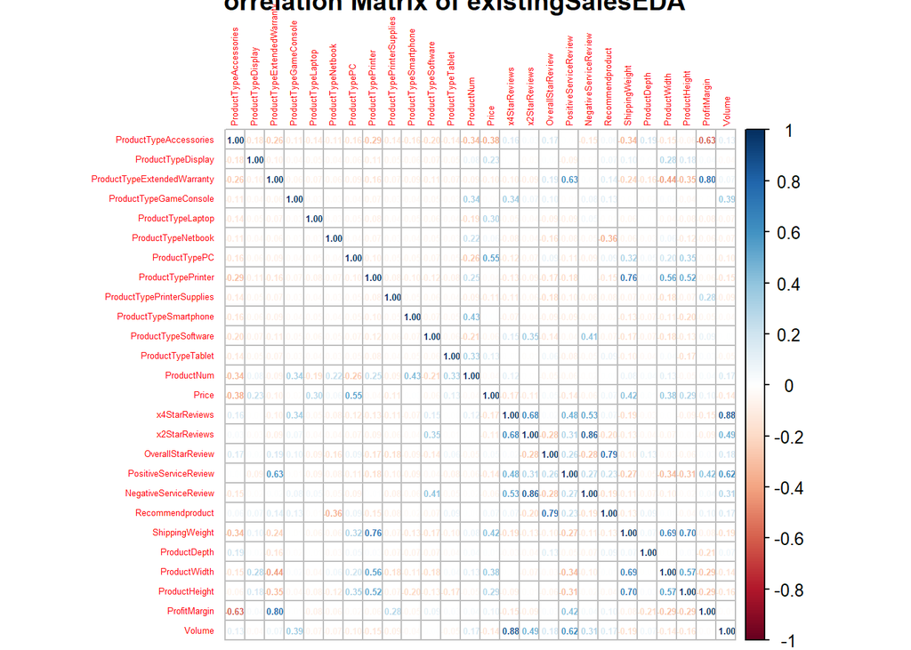

```r
#make a copy of the data
existingSalesEDA <- copy(existing_product)

# Remove column with NA values "BestsellerRanks"
existingSalesEDA$BestSellersRank <- NULL

#Get the weighted mean of the Star reviews
existingSalesEDATrans <- existingSalesEDA %>%
 mutate(
  OverallStarReview = round((x5StarReviews*5 + x4StarReviews*4 + x3StarReviews*3 + x2StarReviews*2 + x1StarReviews*1) / (x5StarReviews + x4StarReviews + x3StarReviews + x2StarReviews + x1StarReviews),digits = 1),
  .after = x1StarReviews
 ) %>%
  select(-x5StarReviews, -x3StarReviews, -x1StarReviews)

existingSalesEDA$OverallStarReview <- existingSalesEDATrans$OverallStarReview
# copy data for correlation analysis


# Dummify Sales by creating  variable for each product type
dummyfiedData <- dummyVars('~.', data = existingSalesEDATrans)

existingSalesEDATransDummified <- data.frame(predict(dummyfiedData, newdata = existingSalesEDATrans))


# define and plot a correlation matrix
correlationData <- copy(existingSalesEDA)
correlationData$ProductType <-NULL
correlationData$ProductNum  <-NULL

corrold <- cor(correlationData)
corrDataDummy <- cor(existingSalesEDATransDummified)

#png(filename = "corrplot.png", width = 1200, height = 800)
corrplot(corrDataDummy,method = 'number',addCoef.col = 1,number.cex = 0.4, tl.cex = 0.4, title = 'orrelation Matrix of existingSalesEDA')
```

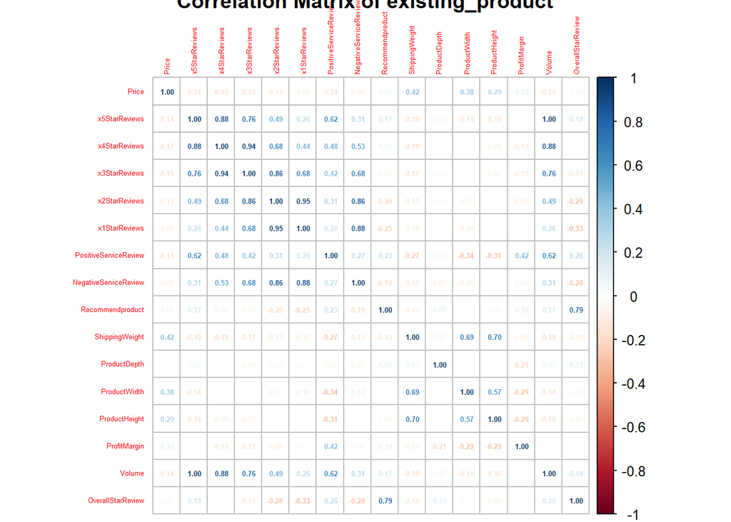

```r
corrplot(corrold,method = 'number',addCoef.col = 1,number.cex = 0.4, tl.cex = 0.4, title='Correlation Matrix of existing_product')
```

```r
new_product<-read.csv("newproductattributes2017.csv")

# Remove column with NA values "BestsellerRanks"
new_product$BestSellersRank <- NULL

#Get the weighted mean of the Star reviews
new_productsTrans <- new_product %>%
 mutate(
  OverallStarReview = round((x5StarReviews*5 + x4StarReviews*4 + x3StarReviews*3 + x2StarReviews*2 + x1StarReviews*1) / (x5StarReviews + x4StarReviews + x3StarReviews + x2StarReviews + x1StarReviews),digits = 1),
  .after = x1StarReviews
 ) %>%
  select(-x5StarReviews, -x3StarReviews, -x1StarReviews)

# Dummify Sales by creating  variable for each product type
newDummyfiedData <- dummyVars('~.', data = new_productsTrans)

newProductsTransDummy <- data.frame(predict(newDummyfiedData, newdata = new_productsTrans))
newnew <- copy(newProductsTransDummy)
```

## Removing Outliers in Volume

The data distribution of the volume shows the presence of two outliers that could be impact the prediction of volume of sales.

# Data Exploration

This section explores the existing sales for insights.

- In order to better explore the existing sales data the uni-variant and bi variant analysis will be carried out to understand their relationships with the volume of sales of each product

## Uni- Variant Analysis

We discuss the uni variant analysis of the data set and see how they are distributed across the data set.

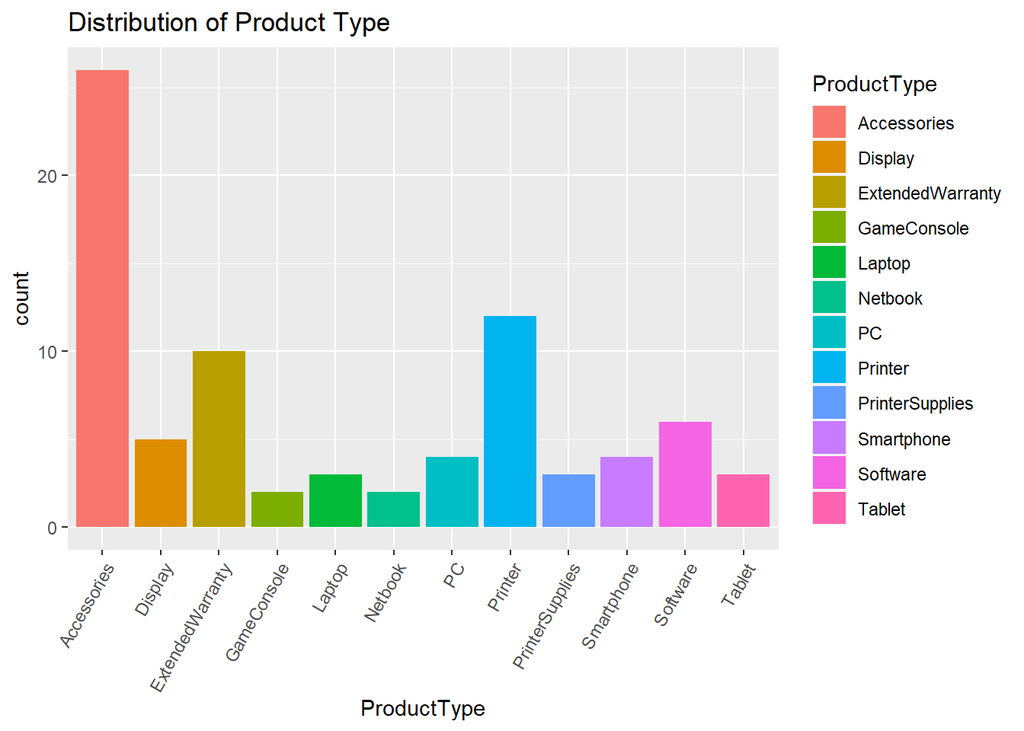

```r
uniVarPlot <- ggplot(data = existingSalesEDA)

p1 <- uniVarPlot +
        geom_bar(aes(x=ProductType, fill = ProductType)) +
        labs(title = 'Distribution of Product Type') +
        theme(axis.text.x = element_text(angle=60, hjust=1))

p2 <- uniVarPlot +
        geom_density(aes(x= Price)) +
        labs(title = 'Distribution of Price')

p3 <- uniVarPlot +
  geom_density(aes(x= OverallStarReview)) +
  labs(title = 'Distribution of Overall Star Reviews')

p4 <- uniVarPlot +
  geom_density(aes(x= x5StarReviews)) +
  labs(title = 'Distribution of 5 Star Reviews')

p5 <- uniVarPlot +
  geom_density(aes(x= x4StarReviews)) +
  labs(title = 'Distribution of 4 Star Reviews')

p6 <- uniVarPlot +
  geom_density(aes(x= x3StarReviews)) +
  labs(title = 'Distribution of 3 Star Reviews')

p7 <- uniVarPlot +
  geom_density(aes(x= x2StarReviews)) +
  labs(title = 'Distribution of 2 Star Reviews')

p8 <- uniVarPlot +
  geom_density(aes(x= x1StarReviews)) +
  labs(title = 'Distribution of 1 Star Reviews')

p9 <- uniVarPlot +
  geom_density(aes(x=PositiveServiceReview)) +
  labs(title = 'Distribution of Positive Service Reviews')

p10 <- uniVarPlot +
  geom_density(aes(x=NegativeServiceReview)) +
  labs(title = 'Distribution of Negative Service Reviews')

p11 <- uniVarPlot +
  geom_density(aes(x=Recommendproduct)) +
  labs(title = 'Distribution of Recommend Product')

p12 <- uniVarPlot +
  geom_density(aes(x=ShippingWeight)) +
  labs(title = 'Distribution of Shipping Weight')

p13 <-uniVarPlot +
  geom_density(aes(x=ProductDepth)) +
  labs(title = 'Distribution of Product Depth')

p14 <- uniVarPlot +
  geom_density(aes(x=ProductWidth)) +
  labs(title = 'Distribution of Product Width')

p15 <- uniVarPlot +
  geom_density(aes(x=ProductHeight)) +
  labs(title = 'Distribution of Product Height')

p16 <- uniVarPlot +
  geom_density(aes(x=ProfitMargin)) +
  labs(title = 'Distribution of Profit Margin')

p17 <- uniVarPlot +
  geom_density(aes(x=Volume)) +
  labs(title = 'Distribution of Volume of Sales')

plot_list1 <- list(p2,p3,p4,p5,p6,p7)
plot_list2 <- list(p8,p9,p10,p11,p12,p13)
plot_list3 <- list(p14,p15,p16,p17)

p1
```

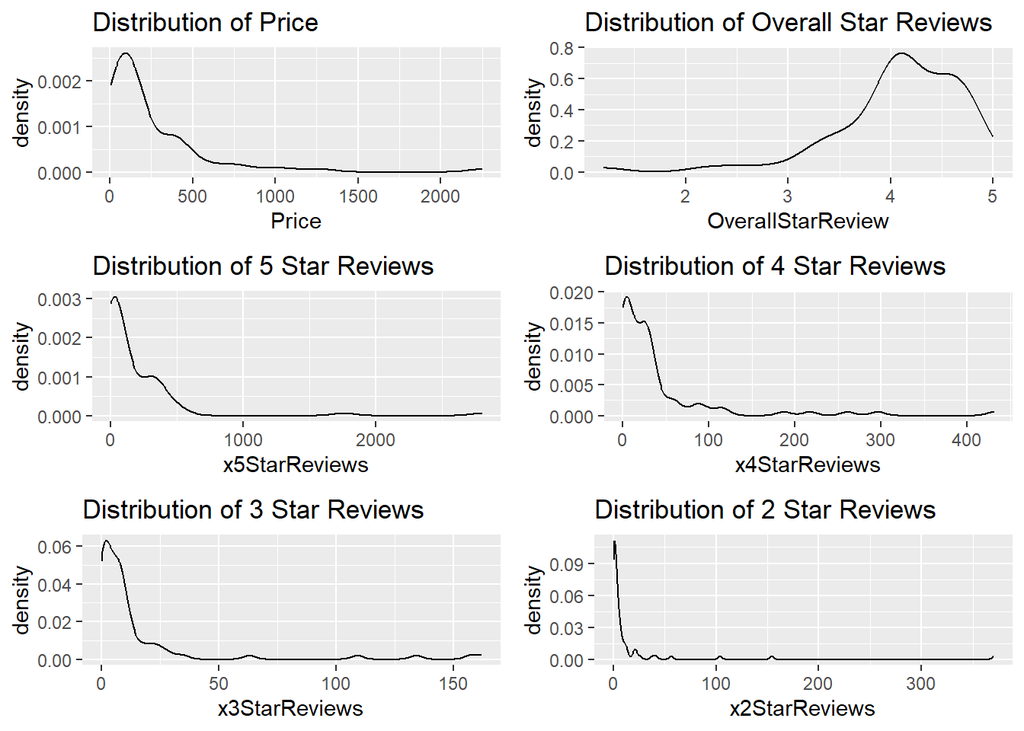

```r
do.call('grid.arrange',c(plot_list1,ncol=2, nrow=3))
```

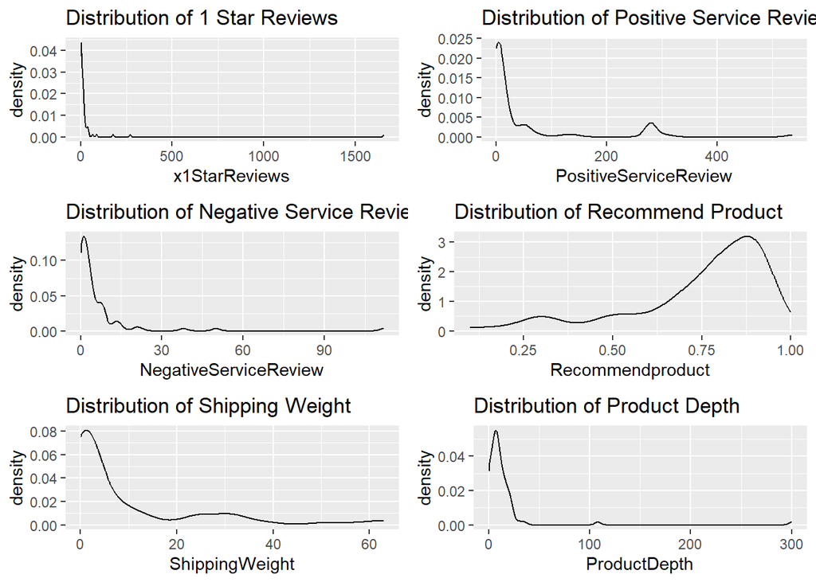

```r
do.call('grid.arrange',c(plot_list2,ncol=2, nrow=3))
```

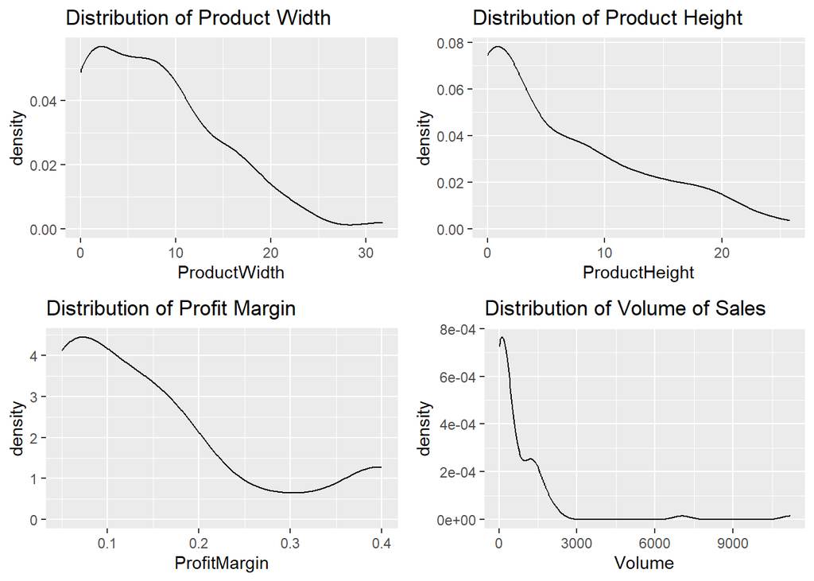

```r
do.call('grid.arrange',c(plot_list3,ncol=2, nrow=2))
```

INSIGHTS

- The distribution of volume shows some few products with extreme volume sales in the data set. This will be further investigated
- The distribution of the product types has Accessories as the highest, Game console as the least, The distribution of PC, Netbook, Smartphone and Laptops each have a count of less than five.
- The distribution of OverallStarReview shows majority of the products had an average rating between 3.7 to 4.7 stars,
- The distribution of 5,4,3,2,1 star shows that we have more customers rating our products on 5 star and the progression goes downward as the star goes to 1.
- The Distribution of positive service reviews seems to be higher then the negative reviews which shows we have more positive feedbacks than the negative feedbacks on our services

## Bi- Variant and Multi Variant Analysis

This analysis shows the relationships between two variables of the data set. since we want to predict Volume of sales of each product, it will be interesting to see the relationships with other variables.

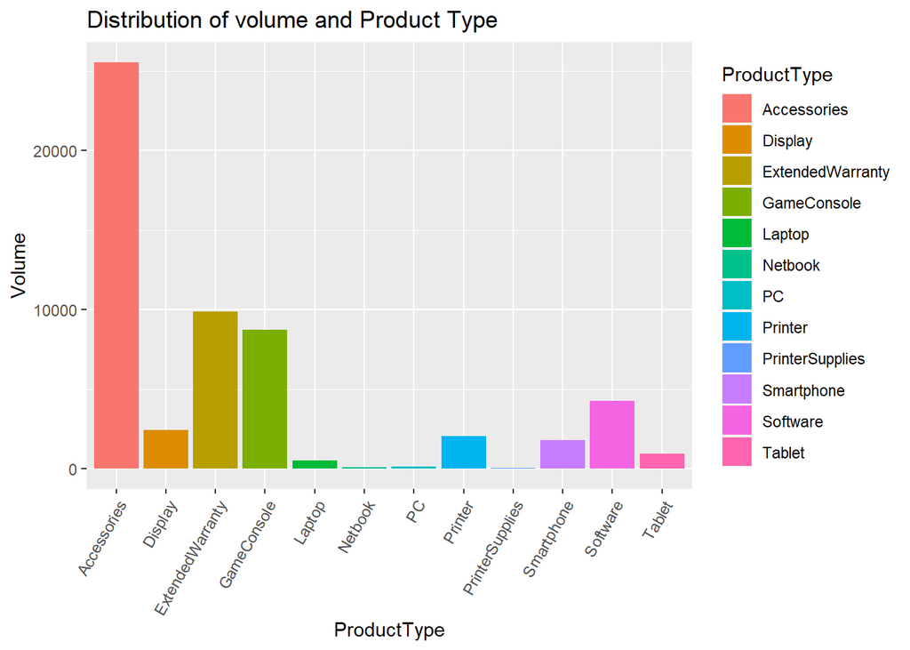

```r
biVarPlot <- ggplot(data=existingSalesEDA)

biVarPlot +
  geom_col(aes(y=Volume,x= ProductType, fill=ProductType)) +
  labs(title='Distribution of volume and Product Type') +
  theme(axis.text.x = element_text(angle=60, hjust=1))
```

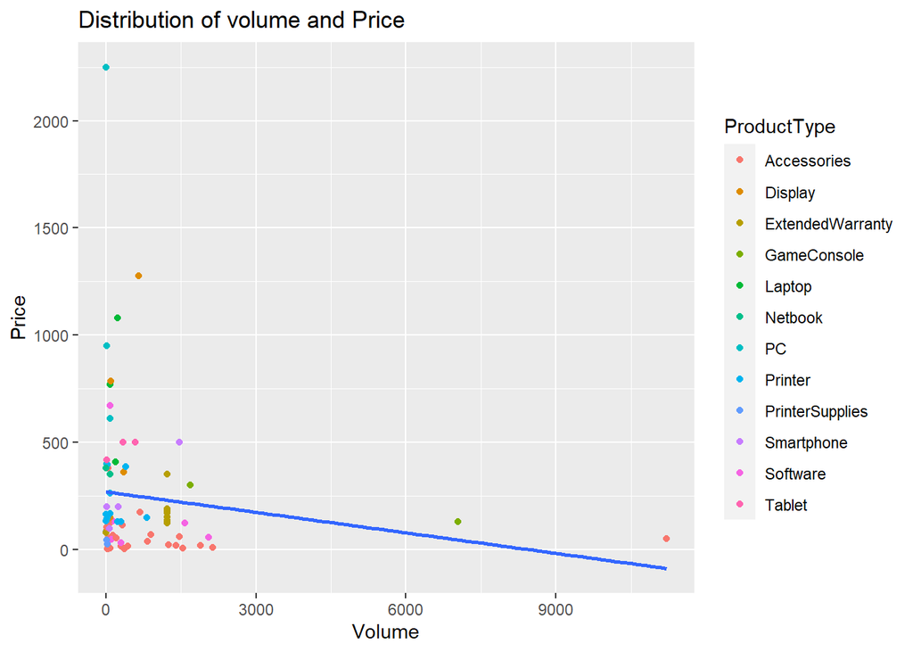

```r
biVarPlot +
  geom_point(aes(x=Volume,y=Price, col=ProductType)) +
  geom_smooth(method = 'lm', se=FALSE,aes(x=Volume,y=Price)) +
  labs(title='Distribution of volume and Price')
```

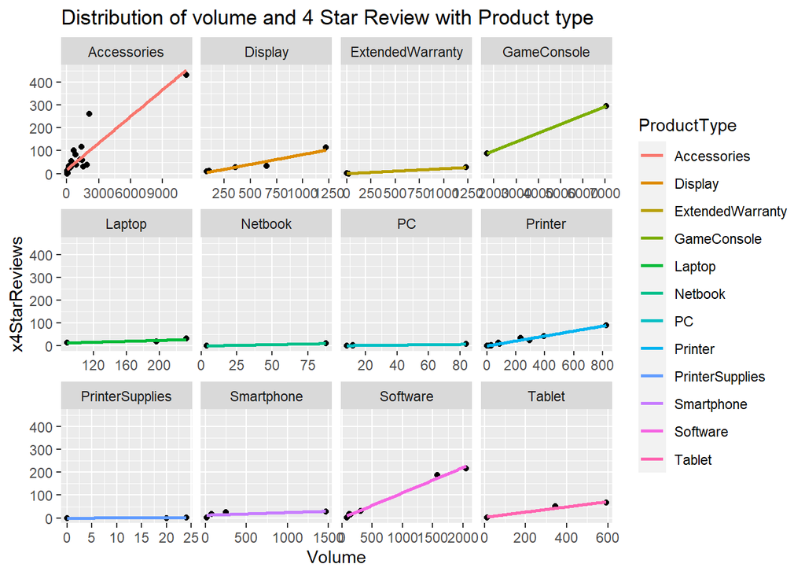

```r
biVarPlot +
  geom_point(aes(x=Volume,y=x4StarReviews)) +
  geom_smooth(method = 'lm', se=FALSE,aes(x=Volume,y=x4StarReviews,col=ProductType)) +
  facet_wrap(~ProductType, scales='free_x') +
  labs(title='Distribution of volume and 4 Star Review with Product type')
```

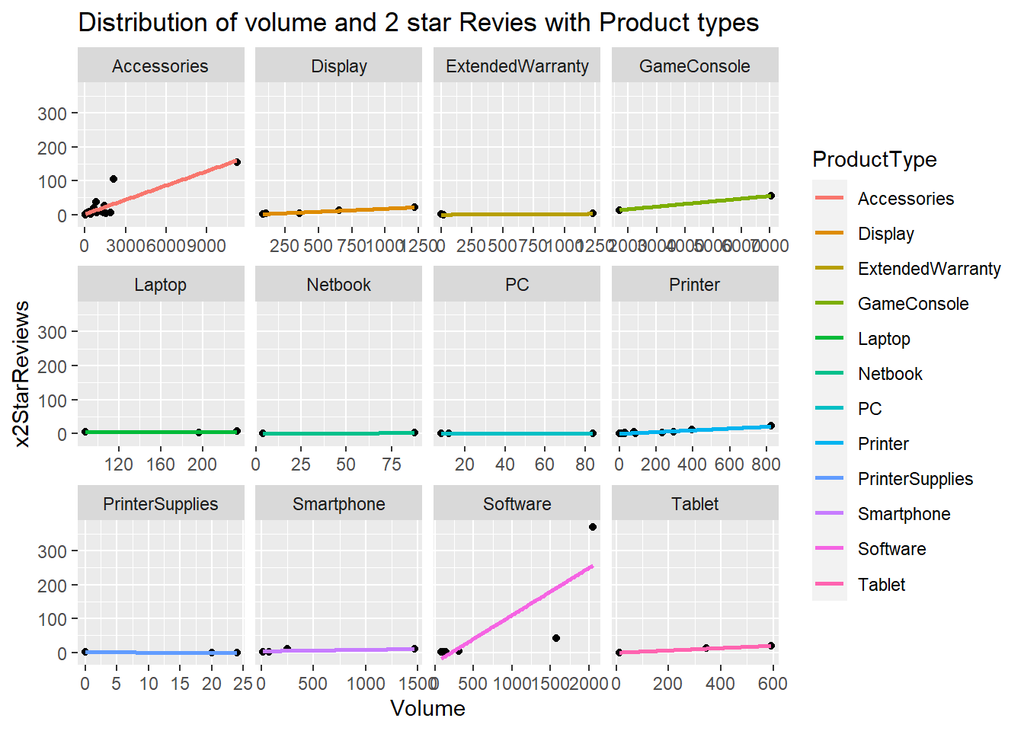

```r
biVarPlot +
  geom_point(aes(x=Volume,y=x2StarReviews)) +
  geom_smooth(method = 'lm', se=FALSE,aes(x=Volume,y=x2StarReviews, color=ProductType)) +
  facet_wrap(~ProductType, scales='free_x') +
  labs(title='Distribution of volume and 2 star Revies with Product types')
```

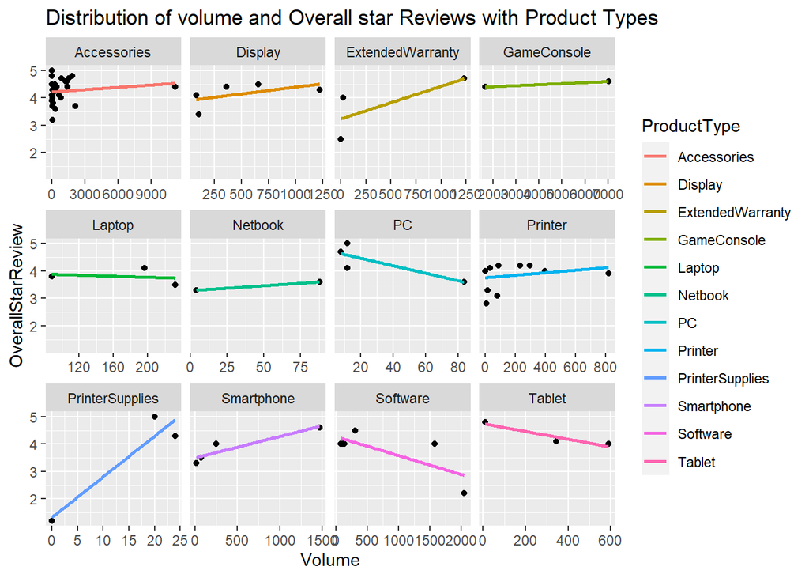

```r
biVarPlot +
  geom_point(aes(x=Volume,y=OverallStarReview)) +
  geom_smooth(method = 'lm',se=FALSE,aes(x=Volume,y = OverallStarReview, color=ProductType)) +
  facet_wrap(~ProductType, scales = 'free_x') +
  labs(title='Distribution of volume and Overall star Reviews with Product Types')
```

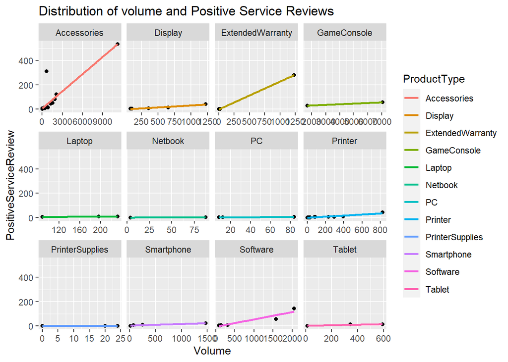

```r
biVarPlot +
  geom_point(aes(x=Volume,y=PositiveServiceReview)) +
  geom_smooth(method = 'lm', se=FALSE,aes(x=Volume,y=PositiveServiceReview,color=ProductType)) +
  facet_wrap(~ProductType,scales = 'free_x') +
  labs(title='Distribution of volume and Positive Service Reviews')
```

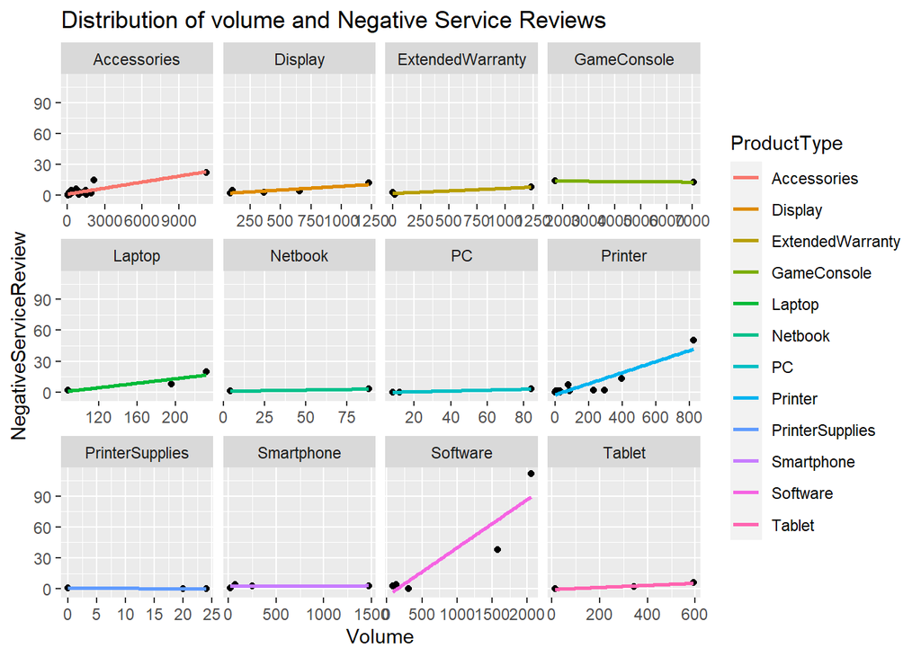

```r
biVarPlot +
  geom_point(aes(x=Volume,y=NegativeServiceReview)) +
  geom_smooth(method = 'lm', se=FALSE,aes(x=Volume,y=NegativeServiceReview,color=ProductType)) +
  facet_wrap(~ProductType,scales = 'free_x') +
  labs(title='Distribution of volume and Negative Service Reviews')
```

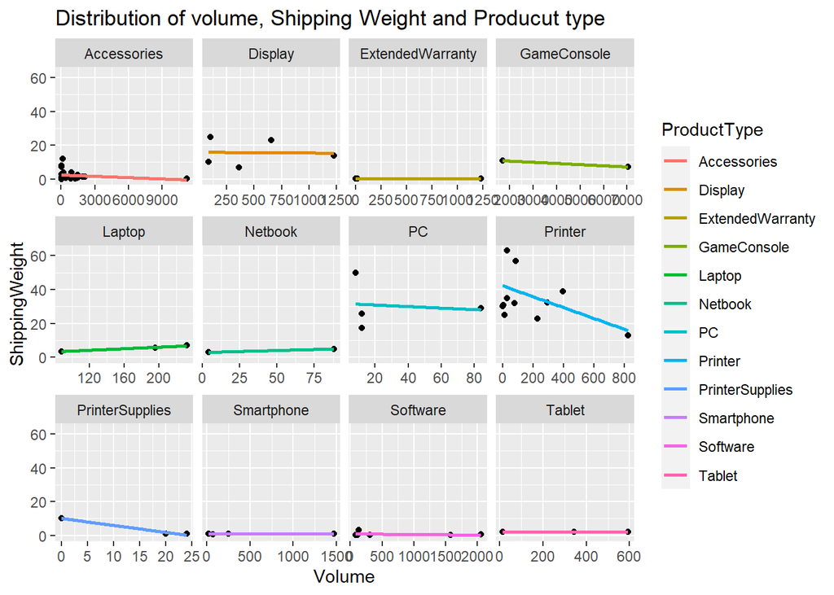

```r
biVarPlot +
  geom_point(aes(x=Volume,y=ShippingWeight)) +
  geom_smooth(method = 'lm', se=FALSE,aes(x=Volume,y=ShippingWeight,color=ProductType)) +
  facet_wrap(~ProductType,scales = 'free_x')+
  labs(title='Distribution of volume, Shipping Weight and Producut type')
```

The modeling phase describes the process of modeling our sales data

## Feature Selection and Engineering

After a careful observation of the training data set, we observed that the following variables have no values that could be compared and eventually not contributing to prediction of the target variable “Volume” or they are in significant to predicting the volume of sales. This is due to one of the limitations of data set “few records” where given.

The feature selection process helps to determine the importance of the variables that will be used in predicting the volumes of sales of products

Every other features or variables aside the following given below will be used in predicting the volume based on the absence of values to compare during the modeling.

```r
#existingSalesOutliersRemoved
```

```r
# Remove variables with no values to compare in the training set.
existingSalesOutliersRemoved$ProductNum <- NULL
existingSalesOutliersRemoved$ProductTypeGameConsole <- NULL
existingSalesOutliersRemoved$ProductTypePrinterSupplies <- NULL
existingSalesOutliersRemoved$ProductTypeDisplay <- NULL
```

#splittingDataSet

```r
#Setting seed
set.seed(234)

# Splitting data set into train and test
index <- createDataPartition(existingSalesOutliersRemoved$Volume, p = 0.70, list = FALSE)
trainSet <- existingSalesOutliersRemoved[index, ]
testSet <- existingSalesOutliersRemoved[-index, ]

fitControl <- trainControl(method = "repeatedcv", number = 5, repeats =3)
```

## Training Models

### Training data set with KNN Model

```r
set.seed(167)
tunegridknn <- expand.grid(k = c(5,7,9,11,13,15,17))
modelKNN <- train(Volume ~ .,
                      method = "knn",
                      data = trainSet,
                      tuneGrid = tunegridknn,
                      trControl=fitControl,preProcess = c("center", "scale"))
print(modelKNN)
```

```
## k-Nearest Neighbors
##
## 56 samples
## 21 predictors
##
## Pre-processing: centered (21), scaled (21)
## Resampling: Cross-Validated (5 fold, repeated 3 times)
## Summary of sample sizes: 45, 44, 45, 44, 46, 44, ...
## Resampling results across tuning parameters:
##
##   k   RMSE      Rsquared   MAE
##    5  259.4626  0.7418671  164.3837
##    7  297.3984  0.7111264  198.7206
##    9  320.6094  0.6997667  229.1696
##   11  352.3906  0.6813034  259.2957
##   13  382.6201  0.6431803  286.1168
##   15  408.5732  0.5844263  308.3732
##   17  427.1651  0.5518646  324.9928
##
## RMSE was used to select the optimal model using the smallest value.
## The final value used for the model was k = 5.
```

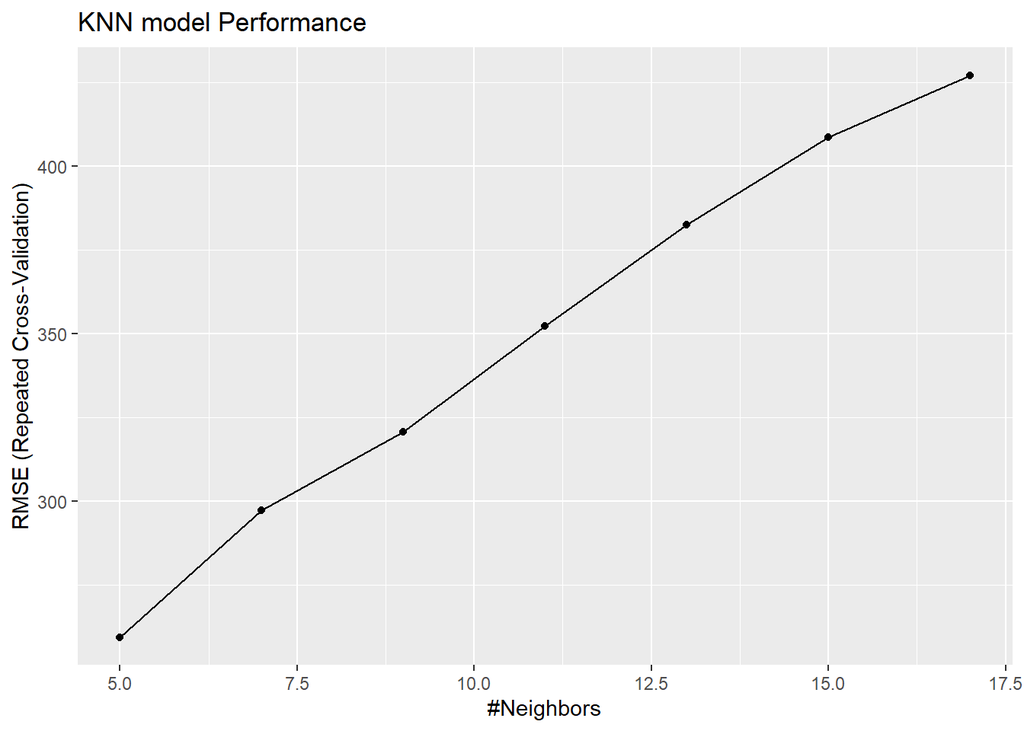

```r
ggplot(modelKNN) + labs(title = 'KNN model Performance')
```

INSIGHTS

- The use of KNN in modeling our data set shows that most acceptable average error in the predicted and actual values is when k was 5
- An average error of 259 unit of sales more or less( plus or minus),
- we can also observe that the variables used with the KNN model has a 74 percent contribution in predicting the volume of sales.

### Training data set with LInear Regression Model

```r
set.seed(125)

modelLM <- train(Volume ~ .,
                      method = "lm",
                      data = trainSet,
                      tuneLength = 5,
                      trControl=fitControl,preProcess = c("center", "scale"))
print(modelLM)
```

```
## Linear Regression
##
## 56 samples
## 21 predictors
##
## Pre-processing: centered (21), scaled (21)
## Resampling: Cross-Validated (5 fold, repeated 3 times)
## Summary of sample sizes: 45, 45, 44, 45, 45, 45, ...
## Resampling results:
##
##   RMSE      Rsquared   MAE
##   486.8327  0.7183814  248.8252
##
## Tuning parameter 'intercept' was held constant at a value of TRUE
```

```r
#ggplot(modelLM) + labs(title = 'LM model Performance')
```

INSIGHTS

- The use of Linear regression in modeling our data set shows that most acceptable average error in the predicted and actual values is plus or minus 486 units of sales
- An average absolute error of 249 unit of sales more or less( plus or minus),
- we can also observe that the variables used with the Linear Regression model has a 71 percent contribution in predicting the volume of sales.

### Training data set with Gradient Boosting Machine Model

```r
set.seed(125)
gbmGrid <-  expand.grid(interaction.depth = c(1,2,3),
                        n.trees = (1:4)*50,
                        shrinkage = 0.1,
                        n.minobsinnode = 10)
modelGBM <- train(Volume ~ .,
                      method = "gbm",
                      data = trainSet,
                      tuneGrid = gbmGrid,
                      trControl=fitControl,preProcess = c("center", "scale"),
                      verbose= FALSE)
print(modelGBM)
```

```
## Stochastic Gradient Boosting
##
## 56 samples
## 21 predictors
##
## Pre-processing: centered (21), scaled (21)
## Resampling: Cross-Validated (5 fold, repeated 3 times)
## Summary of sample sizes: 45, 45, 44, 45, 45, 45, ...
## Resampling results across tuning parameters:
##
##   interaction.depth  n.trees  RMSE      Rsquared   MAE
##   1                   50      250.8158  0.7833066  183.5059
##   1                  100      248.9513  0.7867721  179.9841
##   1                  150      245.3634  0.7890704  175.3250
##   1                  200      246.3439  0.7886249  173.4179
##   2                   50      252.6373  0.7871372  183.9133
##   2                  100      253.1472  0.7839369  183.2591
##   2                  150      252.8173  0.7842947  180.9149
##   2                  200      252.8594  0.7844230  180.0397
##   3                   50      251.4354  0.7846963  182.6550
##   3                  100      249.6044  0.7853979  181.7150
##   3                  150      249.6652  0.7862499  182.6772
##   3                  200      250.1441  0.7880430  179.9754
##
## Tuning parameter 'shrinkage' was held constant at a value of 0.1
##
## Tuning parameter 'n.minobsinnode' was held constant at a value of 10
## RMSE was used to select the optimal model using the smallest value.
## The final values used for the model were n.trees = 150, interaction.depth =
##  1, shrinkage = 0.1 and n.minobsinnode = 10.
```

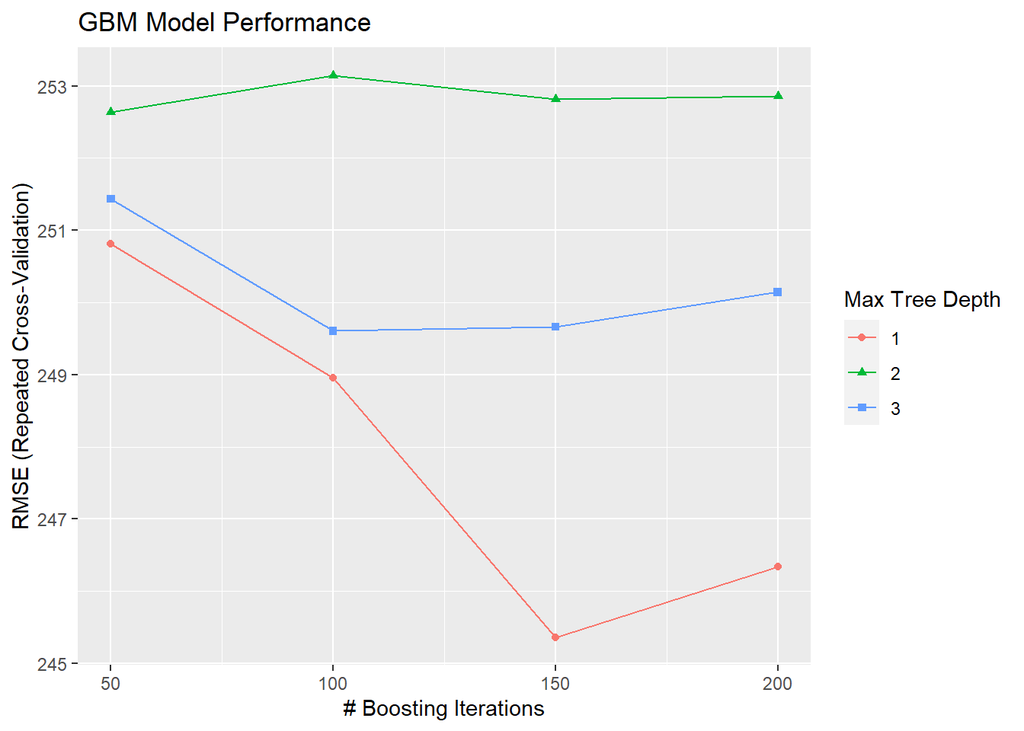

```r
#varImpGBM <- varImp(modelGBM, n.trees =50)

#ggplot(varImpGBM)
ggplot(modelGBM) + labs(title = 'GBM Model Performance')
```

INSIGHTS

### Training Data with Random Forest

```r
set.seed(125)
tunegrid <- expand.grid(mtry = c(8,9,10))
modelRF <- train(Volume ~ .,
                      method = "rf",
                      data = trainSet,
                      tuneGrid = tunegrid,
                      trControl=fitControl,preProcess = c("center", "scale"))
modelRF
```

```
## Random Forest
##
## 56 samples
## 21 predictors
##
## Pre-processing: centered (21), scaled (21)
## Resampling: Cross-Validated (5 fold, repeated 3 times)
## Summary of sample sizes: 45, 45, 44, 45, 45, 45, ...
## Resampling results across tuning parameters:
##
##   mtry  RMSE      Rsquared   MAE
##    8    151.2552  0.9332208  93.92044
##    9    144.3270  0.9392497  87.69283
##   10    137.8426  0.9445949  83.45914
##
## RMSE was used to select the optimal model using the smallest value.
## The final value used for the model was mtry = 10.
```

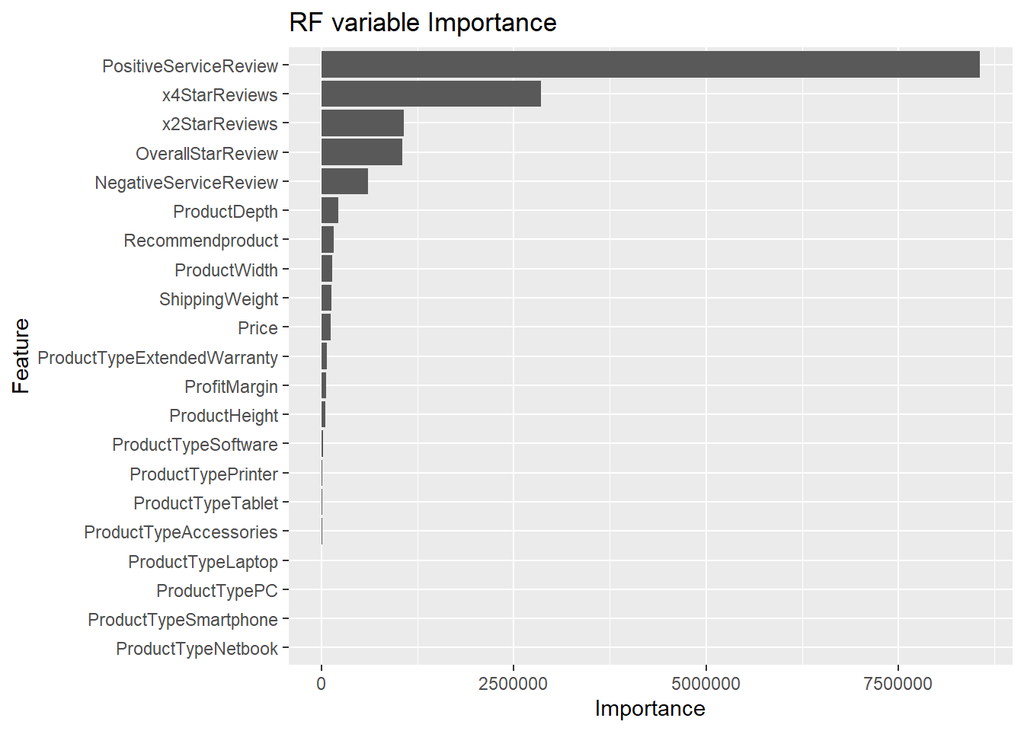

```r
varImpRF <- varImp(modelRF, scale = FALSE)

ggplot(varImpRF) + labs(title = "RF variable Importance")
```

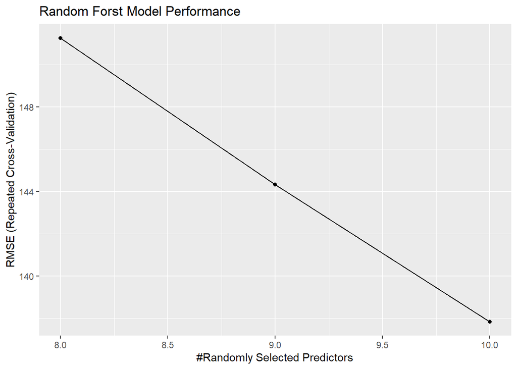

```r
ggplot(modelRF) + labs(title = "Random Forst Model Performance")
```

INSIGHTS

- we can see that the Random forest model has the best performance when the mtry was 10 and an error between predicted and actual value is plus or minus 137 units of sales and predictor contribution of 94 percent

### SVM Modeling

```r
set.seed(125)
tunegridSVM <- expand.grid(C = c(5,6,7), sigma =0.1)
modelSVM <- train(Volume ~ .,
                      method = "svmRadial",
                      data = trainSet,
                      tuneGrid = tunegridSVM,
                      trControl=fitControl,preProcess = c("center", "scale"))
modelSVM
```

```
## Support Vector Machines with Radial Basis Function Kernel
##
## 56 samples
## 21 predictors
##
## Pre-processing: centered (21), scaled (21)
## Resampling: Cross-Validated (5 fold, repeated 3 times)
## Summary of sample sizes: 45, 45, 44, 45, 45, 45, ...
## Resampling results across tuning parameters:
##
##   C  RMSE      Rsquared   MAE
##   5  238.2546  0.8062973  167.9490
##   6  235.3435  0.8092058  166.1196
##   7  234.2587  0.8102506  165.3742
##
## Tuning parameter 'sigma' was held constant at a value of 0.1
## RMSE was used to select the optimal model using the smallest value.
## The final values used for the model were sigma = 0.1 and C = 7.
```

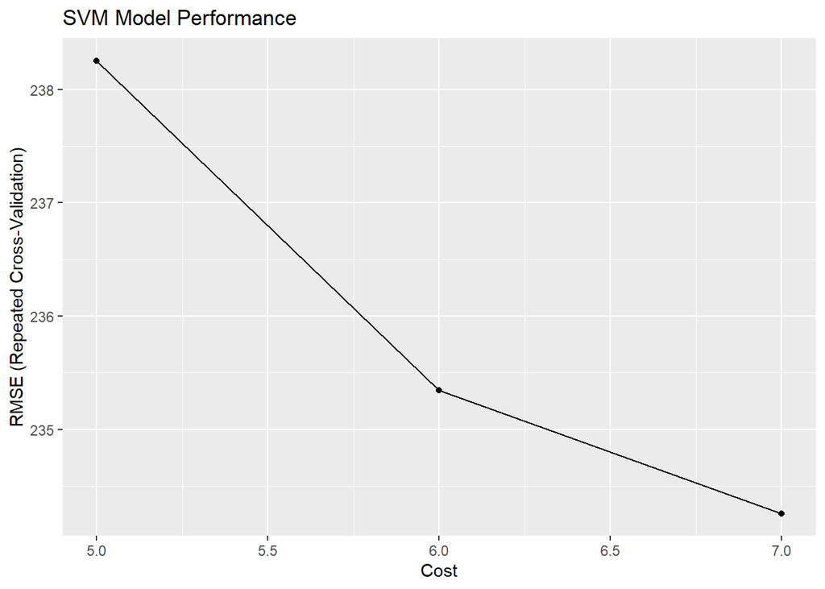

```r
ggplot(modelSVM) + labs(title = "SVM Model Performance")
```

INSIGHTS

- we can see that the support vector Machine model has the best performance when the cost was 7 and an error between predicted and actual value is plus or minus 234 units of sales and predictor contribution of 81 percent

## Comparing Trained Models

In order to select the best model, we check the mean error of the predicted and the actual as follows.

```r
compareResult <- resamples(list(LM =modelLM ,RF=modelRF, GBM=modelGBM, SVM=modelSVM, KNN=modelKNN))

summary(compareResult)
```

```
##
## Call:
## summary.resamples(object = compareResult)
##
## Models: LM, RF, GBM, SVM, KNN
## Number of resamples: 15
##
## MAE
##          Min.   1st Qu.    Median      Mean  3rd Qu.     Max. NA's
## LM  106.06706 165.19372 231.80142 248.82518 338.1881 397.5020    0
## RF   37.47953  65.22857  85.51281  83.45914 100.5626 124.5282    0
## GBM  98.21107 151.83456 168.46899 175.32505 189.5870 242.5813    0
## SVM  74.42776 125.58093 168.15794 165.37416 204.0984 250.2189    0
## KNN  58.31111 124.86667 169.76000 164.38373 201.0667 260.9600    0
##
## RMSE
##          Min.   1st Qu.   Median     Mean  3rd Qu.     Max. NA's
## LM  169.16362 258.98614 365.5914 486.8327 709.2377 980.9058    0
## RF   46.13738  92.22382 146.1357 137.8426 162.5407 242.0447    0
## GBM 120.16197 212.05918 244.9647 245.3634 287.7381 342.5470    0
## SVM  89.17271 161.18977 216.6792 234.2587 280.7514 395.7054    0
## KNN  85.42412 173.45600 248.2471 259.4626 319.7296 469.4626    0
##
## Rsquared
##          Min.   1st Qu.    Median      Mean   3rd Qu.      Max. NA's
## LM  0.3466249 0.6278257 0.7942708 0.7183814 0.8798463 0.9234245    0
## RF  0.8911505 0.9141598 0.9458748 0.9445949 0.9822538 0.9937563    0
## GBM 0.6718650 0.7243767 0.7825966 0.7890704 0.8384049 0.9357161    0
## SVM 0.4748296 0.8140511 0.8456247 0.8102506 0.9338236 0.9826012    0
## KNN 0.3064516 0.6857320 0.8211345 0.7418671 0.9189457 0.9760698    0
```

INSIGHTS

- From the comparison above we can see that the random forest model out performed other models with an average error in the predict and actual value of plus or minus 138 unit of sales, and the predictor contribution of 94 percent. Thus we select the Random Forest Model as our best model so far.

## Testing Model

This phase helps us test our model to observe its performance on a new set of data.

```r
#create a factor from the dummified data
convertDummyToFactor <- function(dataframe){
  dataframe <- dataframe %>%
  mutate(

      ProductType = ifelse(ProductTypeLaptop == 1,'Laptop',
                       ifelse(ProductTypeNetbook == 1,'Netbook',
                          ifelse(ProductTypeSmartphone == 1,'Smartphone',
                             ifelse(ProductTypePC == 1,'PC',
                                    ifelse(ProductTypePrinter==1 , 'Printers',
                                     ifelse(ProductTypeAccessories ==1, 'Accessories',
                                        ifelse(ProductTypeExtendedWarranty == 1, 'Extended Warranty',
                                            ifelse(ProductTypeSoftware == 1, 'Software', "Others")))))))),


  .after = Volume
  )

  return(dataframe)
}



convertDummyToFactor2 <- function(dataframe){
  dataframe <- dataframe %>%
  mutate( ProductType = ifelse(ProductTypeLaptop == 1,'Laptop',
                       ifelse(ProductTypeNetbook == 1,'Netbook',
                          ifelse(ProductTypeSmartphone == 1,'Smartphone',
                             ifelse(ProductTypePC == 1,'PC',
                                    ifelse(ProductTypePrinter==1 , 'Printers',
                                     ifelse(ProductTypeAccessories ==1, 'Accessories',
                                        ifelse(ProductTypeExtendedWarranty == 1, 'Extended Warranty',
                                            ifelse(ProductTypeSoftware == 1, 'Software',
                                              ifelse(ProductTypeGameConsole == 1, 'Game Console',
                                                ifelse(ProductTypeDisplay == 1, 'Display',
                                                   ifelse(ProductTypePrinterSupplies == 1 , 'Printer Supplies',
                                                      ifelse(ProductTypePrinter == 1 , 'Printer',
                                                         ifelse(ProductTypeTablet == 1,'Tablet', 'Others'))))))))))))),
  .after = Volume
  )

  return(dataframe)
}
```

```r
# predict volume with test data
testSet$PredRF <- as.integer( predict(modelRF, newdata = testSet))

#find the error between predicted and actual
testSet$Errors <- testSet$Volume - testSet$PredRF

summary(testSet$PredRF)
```

```
##    Min. 1st Qu.  Median    Mean 3rd Qu.    Max.
##   19.00   55.25  224.00  487.59 1081.25 1355.00
```

```r
#RMSE
sqrt(mean((testSet$Volume - testSet$PredRF)^2))
```

```
## [1] 380.0938
```

```r
# R2
cor(testSet$Volume, testSet$PredRF) ^ 2
```

```
## [1] 0.8009432
```

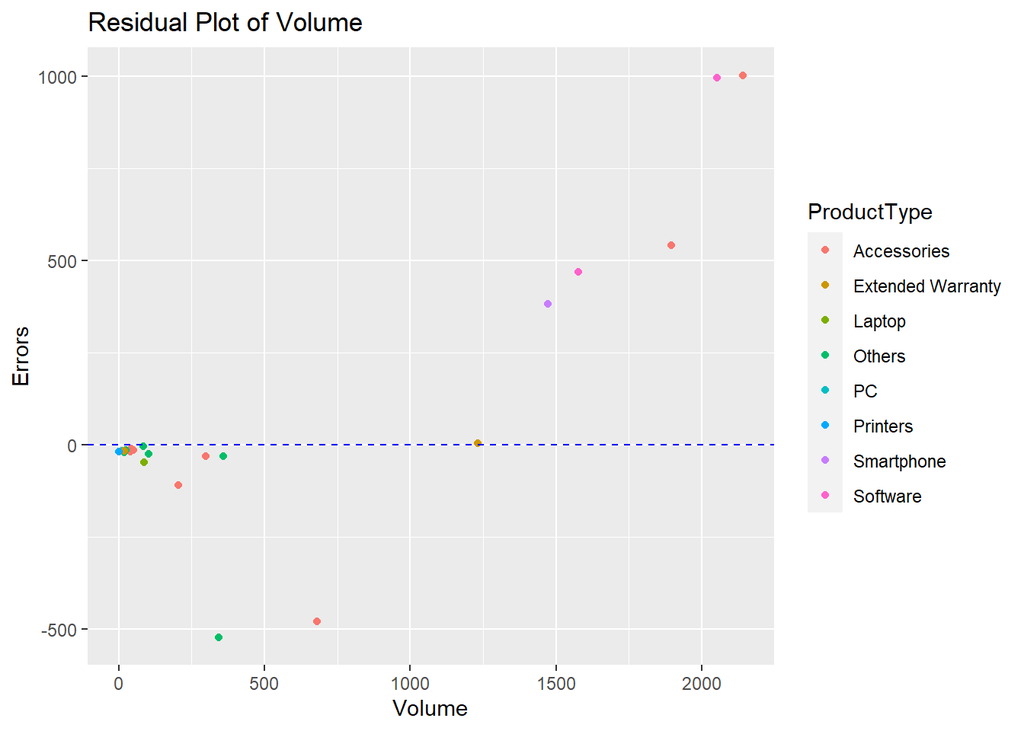

```r
#convert dummy to factor
testSet <- convertDummyToFactor(testSet)

# a plot of the residual values against the independent variables
ggplot(testSet, aes(x=Volume,y=Errors, col=ProductType)) + geom_point() + geom_hline(yintercept=0 , linetype="dashed", color = "blue") +
ggtitle('Residual Plot of Volume')
```

INSIGHTS

- we can see that the **Netbook** one of the products that was of concern to Blackwell was not in the test data set due to the size of the data.
- The RMSE of the error between the predicted and actual is about plus or minus 380 a bit more than what we got during the training phase.
- The predictor contribution or correlation of actual and predicted value is 80 percent

## Predicting with New Products

This section discusses the prediction of the volume of sales of the new product

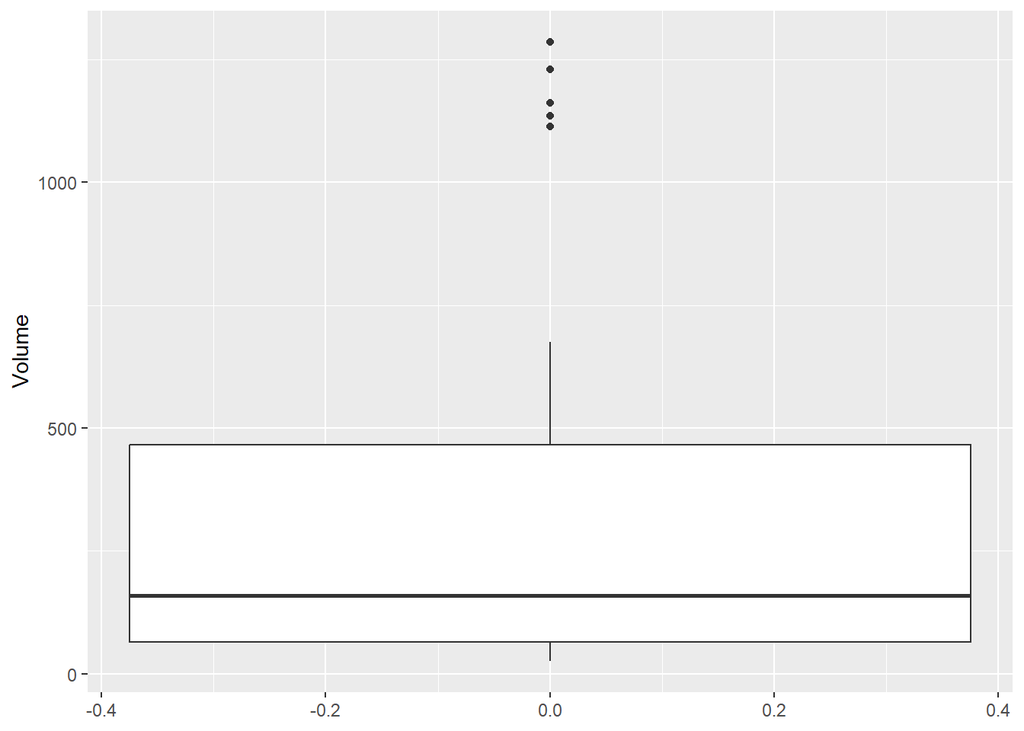

```r
# Remove variables with less importance in predicting volume
newProductsTransDummy$ProductNum <- NULL
newProductsTransDummy$ProductTypeGameConsole <- NULL
newProductsTransDummy$ProductTypePrinterSupplies <- NULL
newProductsTransDummy$ProductTypeDisplay <- NULL


# predict volume of new product
predVolume <- as.integer(predict(modelRF, newdata = newProductsTransDummy))
newProductsTransDummy$Volume <- predVolume

newnew$Volume <- predVolume

#convert product Type dummified data in dataframe to factor data type
newProductsTransDummy <- convertDummyToFactor(newProductsTransDummy)

newnew <- convertDummyToFactor2(newnew)

#Plot graphs of the new product volume predictions
fpred <- ggplot(data = newProductsTransDummy)

fpred + geom_boxplot(aes(y=Volume))
```

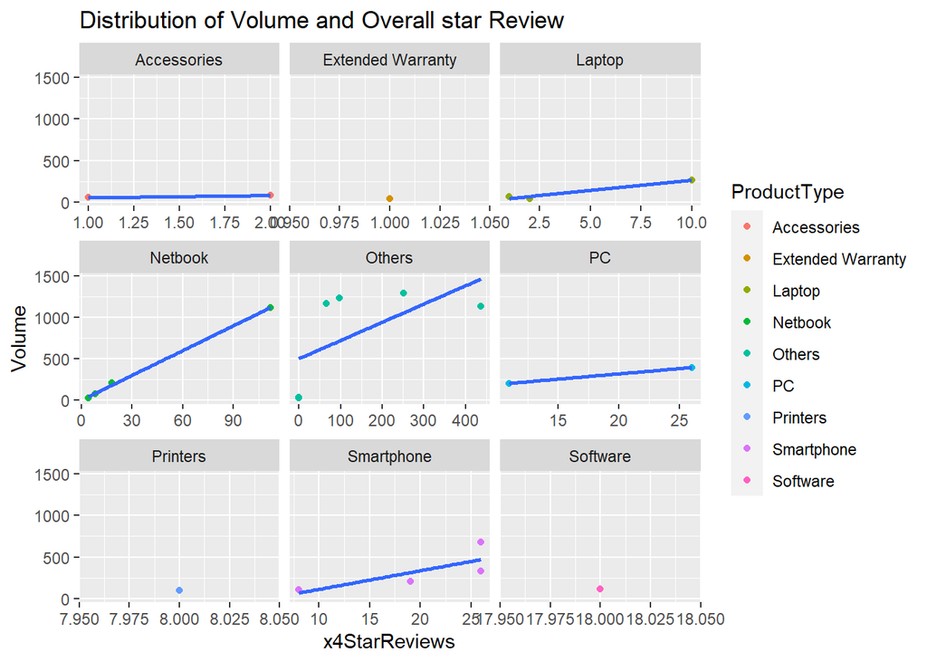

```r
fpred + geom_point(aes(y=Volume, x= x4StarReviews, color=ProductType)) +
  geom_smooth(method = 'lm', se=FALSE, aes(y=Volume, x= x4StarReviews)) + labs(title = 'Distribution of Volume and Overall star Review' ) + facet_wrap(~ProductType, scales = 'free_x')
```

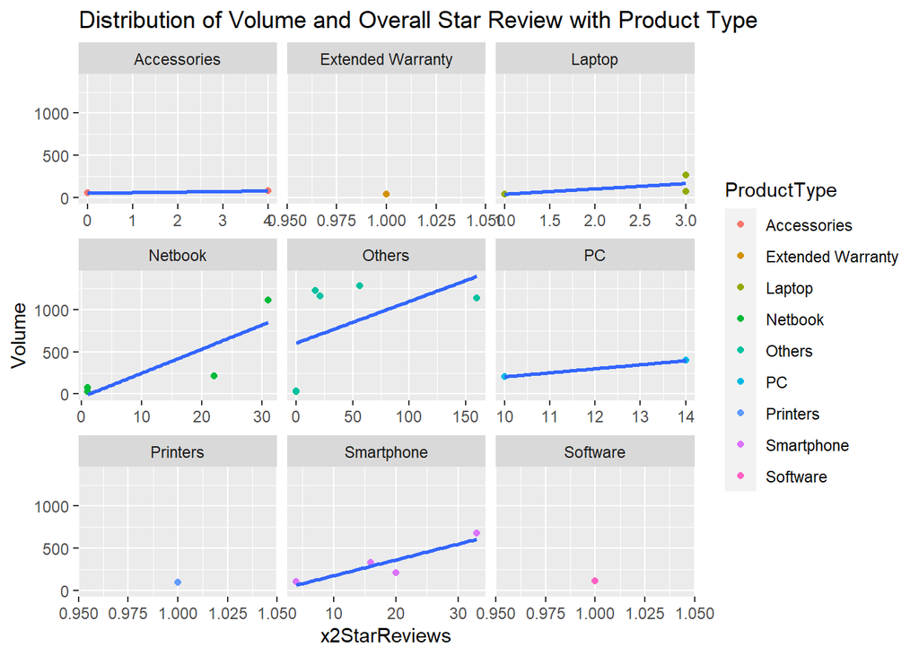

```r
fpred + geom_point(aes(y=Volume, x=x2StarReviews, col= ProductType)) +
  geom_smooth(method = 'lm', se=FALSE,aes(y=Volume, x=x2StarReviews)) +
  facet_wrap(~ProductType, scales = 'free_x')+ labs(title = 'Distribution of Volume and Overall Star Review with Product Type' )
```

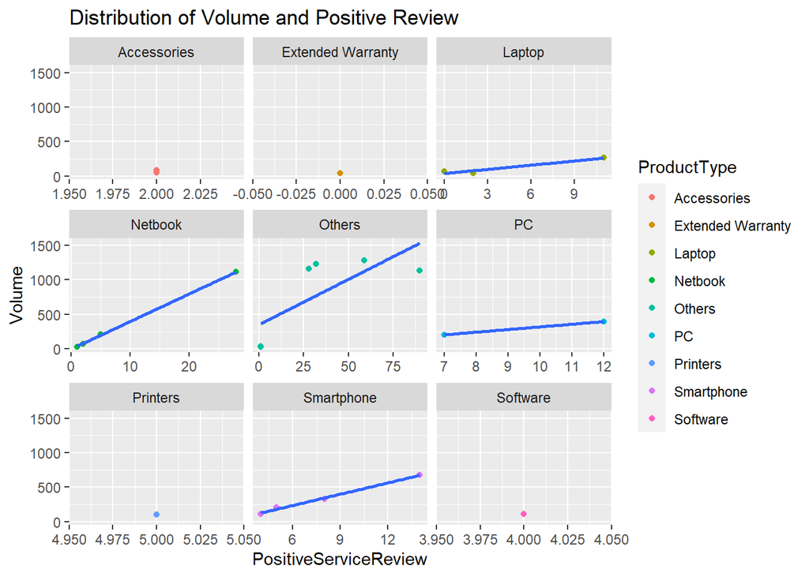

```r
fpred + geom_point(aes(y=Volume, x=PositiveServiceReview, col= ProductType)) +
  geom_smooth(method = 'lm', se=FALSE,aes(y=Volume, x=PositiveServiceReview)) +
  facet_wrap(~ProductType, scales = 'free_x') + labs(title = 'Distribution of Volume and Positive Review' )
```

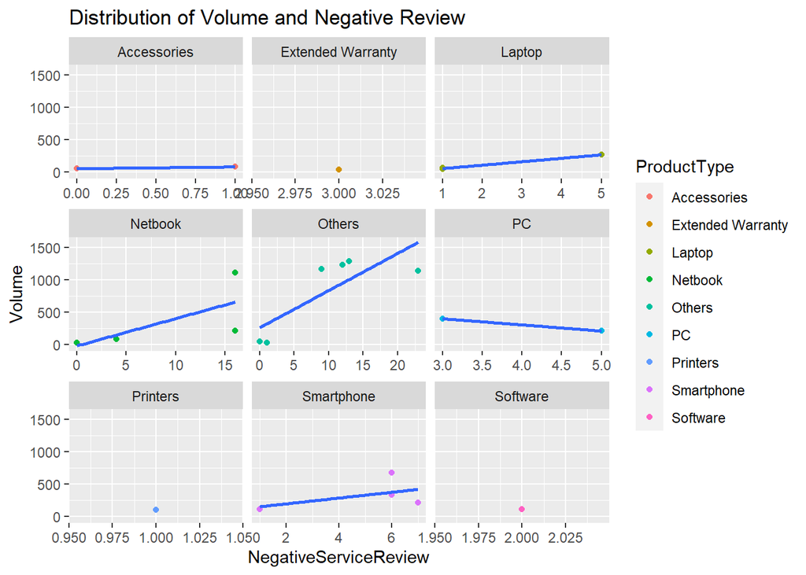

```r
fpred + geom_point(aes(y=Volume, x=NegativeServiceReview, col= ProductType)) +
  geom_smooth(method = 'lm', se=FALSE,aes(y=Volume, x=NegativeServiceReview)) +
  facet_wrap(~ProductType, scales = 'free_x') + labs(title = 'Distribution of Volume and Negative Review' )
```

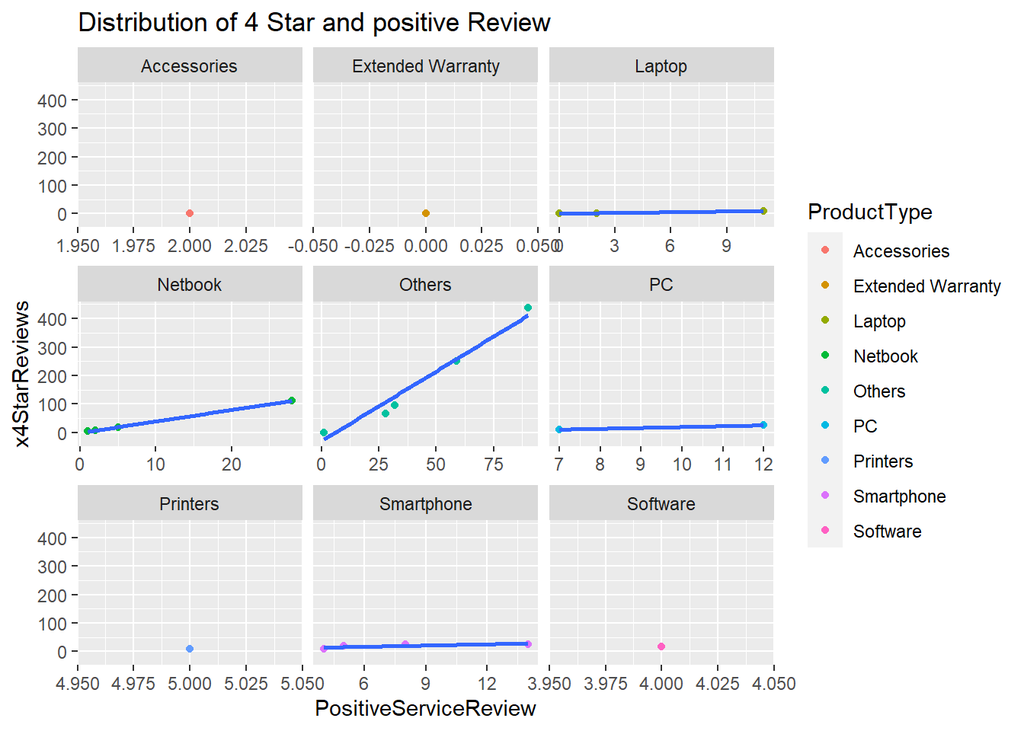

```r
fpred + geom_point(aes(y=x4StarReviews, x=PositiveServiceReview, col= ProductType)) +
  geom_smooth(method = 'lm', se=FALSE,aes(y=x4StarReviews, x=PositiveServiceReview)) +
  facet_wrap(~ProductType, scales = 'free_x') + labs(title = 'Distribution of 4 Star and positive Review' )
```

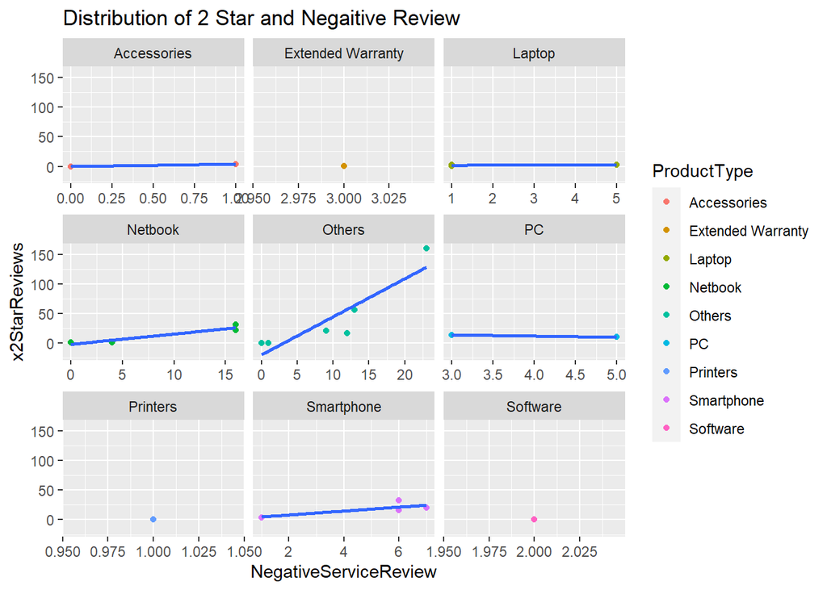

```r
fpred + geom_point(aes(y=x2StarReviews, x=NegativeServiceReview, col= ProductType)) +
  geom_smooth(method = 'lm', se=FALSE,aes(y=x2StarReviews, x=NegativeServiceReview)) + facet_wrap(~ProductType, scales = 'free_x') +
   labs(title = 'Distribution of 2 Star and Negaitive Review' )
```

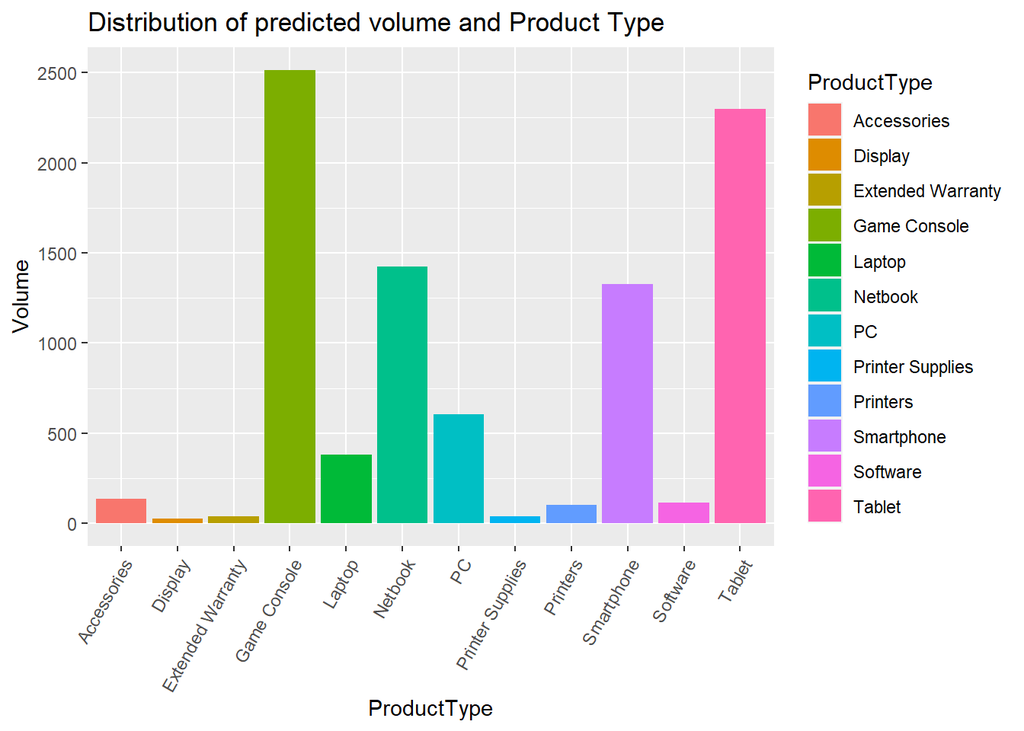

```r
ggplot(data = newnew) +
  geom_col(aes(y=Volume,x= ProductType, fill=ProductType)) +
  labs(title='Distribution of predicted volume and Product Type') +
  theme(axis.text.x = element_text(angle=60, hjust=1))
```

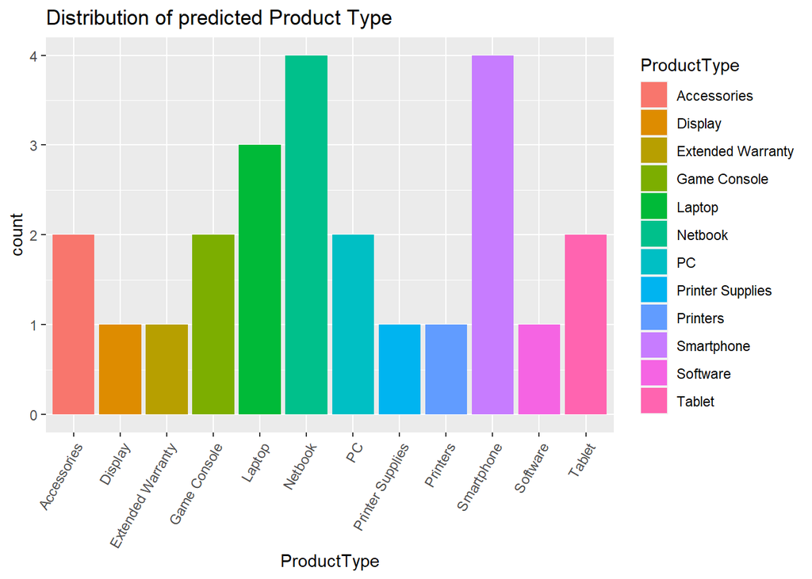

```r
ggplot(data = newnew) +
  geom_bar(aes(x= ProductType, fill=ProductType)) +
  labs(title='Distribution of predicted Product Type') +
  theme(axis.text.x = element_text(angle=60, hjust=1))
```

INSIGHTS

- the distribution of the new Product volume shows that the majority of volume sold was between 0 to 500 unit and some few outliers in the thousands region.
- we can see that for the Four Product types Laptop, Netbook, Smartphones, and PCs distribution with 4 star review shows a near perfect fit for all but smartphones. It also tells us that the more the volume the more the reviews
- we can see that for the Four Product types Laptop, Netbook, Smartphones, and PCs distribution with 2 star review shows a near perfect fit for all but Laptop and Netbook It also tells us that the more the volume the more the reviews
- we can see that for the Four Product types Laptop, Netbook, Smartphones, and PCs distribution with positive service review shows a near perfect fit for all. It also tells us that the more the volume the more the reviews
- we can see that for the Four Product types Laptop, Netbook, Smartphones, and PCs distribution with Negative Service review shows a near perfect fit for all but smartphones and Netbook. It also tells us that the more the volume the more the reviews except for PC products which shows the more the volume the less the negative service reviews
- the distribution of 4 star reviews and positive service review shows a perfect relationship between the two for all products so we can see that the higher the 4 star reviews (positive Customer reviews) the better the positive service review.
- The distribution of the 2 star reviews and the negative service review shows us that the higher the count of 2 star reviews (negative customer reviews) the more the negative service review. There is an exception for Pc the less the 2 star Reviews the more the negative service review

```r
predictedVolumeTable <- knitr::kable(newProductsTransDummy%>%select(ProductType,x4StarReviews,x2StarReviews,PositiveServiceReview,NegativeServiceReview,Volume), format = 'pipe', caption = 'Forecasted Sales for New Product Types', align = 'lccc')

predictedVolumeTable
```

Forecasted Sales for New Product Types

| ProductType | x4StarReviews | x2StarReviews | PositiveServiceReview | NegativeServiceReview | Volume |
| --- | --- | --- | --- | --- | --- |
| PC | 26 | 14 | 12 | 3 | 397 |
| PC | 11 | 10 | 7 | 5 | 206 |
| Laptop | 10 | 3 | 11 | 5 | 268 |
| Laptop | 2 | 1 | 2 | 1 | 42 |
| Laptop | 1 | 3 | 0 | 1 | 69 |
| Netbook | 8 | 1 | 2 | 4 | 75 |
| Netbook | 112 | 31 | 28 | 16 | 1113 |
| Netbook | 18 | 22 | 5 | 16 | 212 |
| Netbook | 4 | 1 | 1 | 0 | 26 |
| Others | 66 | 21 | 28 | 9 | 1162 |
| Others | 437 | 160 | 90 | 23 | 1135 |
| Smartphone | 26 | 16 | 8 | 6 | 331 |
| Smartphone | 26 | 33 | 14 | 6 | 676 |
| Smartphone | 8 | 4 | 4 | 1 | 109 |
| Smartphone | 19 | 20 | 5 | 7 | 209 |
| Others | 97 | 17 | 32 | 12 | 1230 |
| Others | 0 | 0 | 1 | 1 | 26 |
| Accessories | 1 | 0 | 2 | 0 | 54 |
| Accessories | 2 | 4 | 2 | 1 | 81 |
| Software | 18 | 1 | 4 | 2 | 114 |
| Printers | 8 | 1 | 5 | 1 | 101 |
| Others | 0 | 0 | 1 | 0 | 40 |
| Extended Warranty | 1 | 1 | 0 | 3 | 38 |
| Others | 252 | 56 | 59 | 13 | 1286 |

```r
predictedVolumeTable2 <- knitr::kable(newnew%>%select(ProductType,x4StarReviews,x2StarReviews,PositiveServiceReview,NegativeServiceReview,Volume), format = 'pipe', caption = 'Forecasted Sales for New Product Types', align = 'lccc')

predictedVolumeTable2
```

Forecasted Sales for New Product Types

| ProductType | x4StarReviews | x2StarReviews | PositiveServiceReview | NegativeServiceReview | Volume |
| --- | --- | --- | --- | --- | --- |
| PC | 26 | 14 | 12 | 3 | 397 |
| PC | 11 | 10 | 7 | 5 | 206 |
| Laptop | 10 | 3 | 11 | 5 | 268 |
| Laptop | 2 | 1 | 2 | 1 | 42 |
| Laptop | 1 | 3 | 0 | 1 | 69 |
| Netbook | 8 | 1 | 2 | 4 | 75 |
| Netbook | 112 | 31 | 28 | 16 | 1113 |
| Netbook | 18 | 22 | 5 | 16 | 212 |
| Netbook | 4 | 1 | 1 | 0 | 26 |
| Tablet | 66 | 21 | 28 | 9 | 1162 |
| Tablet | 437 | 160 | 90 | 23 | 1135 |
| Smartphone | 26 | 16 | 8 | 6 | 331 |
| Smartphone | 26 | 33 | 14 | 6 | 676 |
| Smartphone | 8 | 4 | 4 | 1 | 109 |
| Smartphone | 19 | 20 | 5 | 7 | 209 |
| Game Console | 97 | 17 | 32 | 12 | 1230 |
| Display | 0 | 0 | 1 | 1 | 26 |
| Accessories | 1 | 0 | 2 | 0 | 54 |
| Accessories | 2 | 4 | 2 | 1 | 81 |
| Software | 18 | 1 | 4 | 2 | 114 |
| Printers | 8 | 1 | 5 | 1 | 101 |
| Printer Supplies | 0 | 0 | 1 | 0 | 40 |
| Extended Warranty | 1 | 1 | 0 | 3 | 38 |
| Game Console | 252 | 56 | 59 | 13 | 1286 |

# Limitations

The following are the limitations of the analysis of the Blackwell new and existing Product data set

- The major limitation is the lack of data to analyse. This has really limited the ranges of techniques that can be used for better analysis.
- Incomplete data representation during modeling phase
- Some key information were missing in the testing data set and could not be analyzed.

# Conclusions